# Project 2: Data Mining, Classification, Prediction

### Non-Parametric Classifier

```r
library(caret)
# non-parametric classifier code here
fit <- knn3(binaryCondition ~ ., data = mariokartNum)
probability <- predict(fit, newdata = mariokartNum)[, 2]
class_diag(probability, mariokartNum$binaryCondition, positive = 1)
```

```
##            acc   sens  spec    ppv     f1     ba   auc
## Metrics 0.8322 0.7627 0.881 0.8182 0.7895 0.8218 0.922
```

```r
table(truth = mariokart$binaryCondition, prediction = (probability >
    0.5)) %>% addmargins
```

```
##      prediction
## truth FALSE TRUE Sum
##   0      74   10  84
##   1      14   45  59
##   Sum    88   55 143
```

```r
74/84  #TNR specificity
```

```
## [1] 0.8809524
```

```r
45/59  #TPR sensitivity/recall
```

```
## [1] 0.7627119
```

```r
14/59  #FPR
```

```
## [1] 0.2372881
```

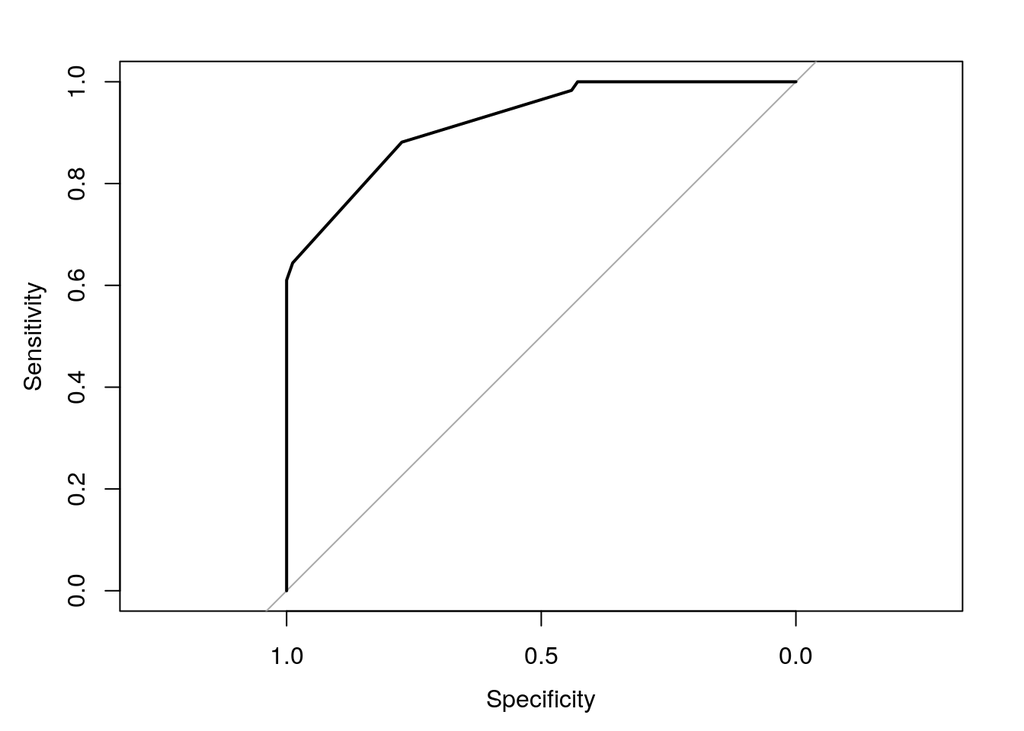

```r
library(pROC)
ROCplot <- plot.roc(mariokartNum$binaryCondition ~ probability)
```

```r
cv <- trainControl(method = "cv", number = 10, classProbs = T,
    savePredictions = T)
fit <- train(binaryCondition ~ ., data = mariokartNum, trControl = cv,
    method = "knn")
class_diag(fit$pred$pred, fit$pred$obs, positive = 1)
```

```
##            acc   sens   spec    ppv     f1     ba    auc
## Metrics 0.7809 0.6949 0.8413 0.7546 0.7235 0.7681 0.8267
```

### Regression/Numeric Prediction

```r
# linear regression
fit <- lm(totalPrice ~ nBids + startPrice, data = mariokart)
yhat <- predict(fit)

# MSE
mean((mariokart$totalPrice - yhat)^2)
```

```
## [1] 618.5681
```

```r
set.seed(1234)
k = 10
data <- mariokart[sample(nrow(mariokart)), ]
folds <- cut(seq(1:nrow(mariokart)), breaks = k, labels = F)
diags <- NULL
for (i in 1:k) {
    train <- data[folds != i, ]
    test <- data[folds == i, ]
    fit <- lm(totalPrice ~ nBids + startPrice, data = train)
    yhat <- predict(fit, newdata = test)
    diags <- mean((test$totalPrice - yhat)^2)
}
mean(diags)
```

```
## [1] 155.8158
```

A linear regression model was also used to attempt to predict the final and total auction price (totalPrice) paid for a copy of MarioKart from the number of bids (nBids) and the starting prince (startPrice). The resulting mean square error was a whopping 618.568 indicating a large amount of error from one or several very biased or high variance estimates for total price. 10-fold cross validation revealed a much lower MSE of 155.816. This signifies that although this linear regression model can be generalized to new data and that there is no sign of overfitting, the final price still cannot be predicted very well by a linear fit probably due to outliers.

### Python

```python
import pandas as pd
mariokart=r.mariokart
highestMKsales = (mariokart.filter(['listingTitle','startPrice','totalPrice','sellerRating']).query('totalPrice > 60').head(5))
```

```r
library(reticulate)
py$highestMKsales
```

```
##                                               listingTitle startPrice
## 4  BRAND NEW NINTENDO 1 WII MARIO KART WITH 2 WHEELS +GAME       0.01
## 19    Nintedo Wii Console Bundle Guitar Hero 5 Mario Kart        1.00
## 22  MARIO KART WITH WII OFFICIAL WHEEL+1 COBALT BLUE WHEEL      64.95
## 38             BRAND NEW NINTENDO MARIO KART WITH 2 WHEELS       1.00
## 64 10 Nintendo Wii Games - MarioKart Wii, SpiderMan 3, etc       6.95
##    totalPrice sellerRating
## 4       71.00          820
## 19     326.51          115
## 22      64.95       118345
## 38      63.99         4858
## 64     118.50           41
```

```r
top5MKauctions <- py$highestMKsales
top5MKauctions %>% arrange(desc(totalPrice))
```

```
##                                               listingTitle startPrice
## 19    Nintedo Wii Console Bundle Guitar Hero 5 Mario Kart        1.00
## 64 10 Nintendo Wii Games - MarioKart Wii, SpiderMan 3, etc       6.95
## 4  BRAND NEW NINTENDO 1 WII MARIO KART WITH 2 WHEELS +GAME       0.01
## 22  MARIO KART WITH WII OFFICIAL WHEEL+1 COBALT BLUE WHEEL      64.95
## 38             BRAND NEW NINTENDO MARIO KART WITH 2 WHEELS       1.00
##    totalPrice sellerRating
## 19     326.51          115
## 64     118.50           41
## 4       71.00          820
## 22      64.95       118345
## 38      63.99         4858
```

The mariokart dataset was accessed in python with “r.”. Only four variables were selected, filtered to total prices higher than 60 dollars, and then the top five total prices were retrieved and saved into highestMKsales. In the R code chunk, highestMKsales was accessed with “$py” and arranged by highest to lowest total price, revealing that the two most expensive auctions actually included other videogames.

### Concluding Remarks

I didn’t enjoy doing this project as much as the first, but was pleased with the dataset I found that matched the guidelines. I am interested to see how the clustering, PCA, and classifiers would differ if I had filtered out any auctions that included more than the Mario Kart game and its accessories because at least two outliers did seem to affect my results. Regardless, its possible that people’s tendencies to spend and bid on items regardless of price or condition could be subject to many different factors that can’t be fitted just to a few models. I fondly remember the lengths my parents went to to get my brother and I our Wii and other games due to their popularity more than 10 years ago, so it isn’t that surprising to me that the features of eBay auctions for a Nintendo game can’t be outright predicted, or at least not from less than 200 observations.